# Introduction to R

## R and RStudio

## The R Project for Statistical Computing

- R is a programming language for statistical computing, specifically designed for data analysis.
- The main implementation is the one available at the **The Comprehensive R Archive Network** (CRAN).
  - Other implementations exist: **Microsoft R Open** (MRAN), **TIBCO® Enterprise Runtime for R** (TERR), …
- R (CRAN) runs on Unix-like systems, Windows and Mac.
- R (CRAN) can be download at https://cran.r-project.org.

## RStudio Desktop

- RStudio Desktop is a free integrated development environment (IDE) for R.
- It incorporates:
  - A **`Console`** pane to execute instructions interactively.
  - An **`Environment`** pane to control existing variables.
  - An R script editor. Supporting other languages: `html`, `css`, `markdown`, `python`, `C/C++`, …
- RStudio Desktop can be download at https://rstudio.com/products/rstudio/download/.
- Other existing IDEs: R tools (in Visual Studio), StatET for R (in Eclipse), Jupyter, … or any text editor: Emacs, Atom, Visual Studio Code, …

## Introduction to R

## Vectors

- **Atomic vectors**.
  - `logical`,
  - `integer`,
  - `numeric`,
  - `character`, and also
  - `raw` and `complex`.
  - Coercing order: `logical` \(\rightarrow\) `integer` \(\rightarrow\) `numeric` \(\rightarrow\) `character`
- **Lists**.

Arrays (`array`) and matrices (`matrix`) are dimensional vectors.

## Non-avaliable value `NA`

- `NA` is a symbol to defined non-availiable observation.
- We can operate with `NA`:

```r
NA + 3
## [1] NA
NA ^ 0
## [1] 1
NA | FALSE
## [1] NA
NA | TRUE
## [1] TRUE
mean( c(1, 3, 2, NA) )
## [1] NA
```

## Functions

Structure:

```r
my_function <- function(...){
  ...
  # Some code
  ...
  return(some_result)
}
```

It is common to avoid the `return()` statement:

```r
my_function <- function(...){
  ...
  # Some code
  ...
  some_result
}
```

## Operators in R

- **Arithmetic**. Addition (`+`), substraction (`-`), multiplication (`*`), division (`/`), and exponentiation (`^`).
  - Modulus (`%%`) and integer division (`%/%`).
- **Logical**. and (`&`), or (`|`).
  - Comparisons: lower than (`<`), greater than (`>`), lower or equal than (`<=`), greater or equal than (`>=`), equal to (`==`), not equal to (`!=`), is in (`%in%`).

## Vector selection

- Positive integers

  ```r
  month.abb[c(1,3,5,7,9,11)]
  ```

- Negative integers

  ```r
  month.abb[c(-1,-3,-5,-7,-9,-11)]
  ```

- Logical vectors

  ```r
  month.abb[c(T,F,T,F,T,F,T,F,T,F,T,F)]
  ```

- Vector of names (only with named vectors)

  ```r
  x = 1:12
  names(x) = month.abb
  x[c("Jan", "Mar", "May", "Jul", "Sep", "Nov")]
  ```

## Iteration in R

- For-structure:

```r
for(i in S){
  ...
  # Some code
  ...
}
```

- Functional iteration:  
  `sapply(x, f)`, `lapply(x, f)`  
  `mapply(f, x1, x2, ...)`

## Activities

- Suppose `queue = c("Maria", "Josep", "Marçal", "Lluïsa")` represents a supermarket queue, with Maria first in line. Using R expressions update the supermarket queue:
  1. Manel arrives;
  2. Maria is served;
  3. Vicens talks her way to the front with one item;
  4. Manel gets impatient and leaves;
  5. Marçal gets impatient and leaves;
- Why is `1 == "1"` true? Why is `-1 < FALSE` true? Why is `"one" < 2` false?
- Why is the default missing value, `NA` (see `is.logical(NA)`), a logical vector? What’s special about logical vectors? (Hint: think about `c(FALSE, NA_character_)`.)

## Repositories and packages

## R packages

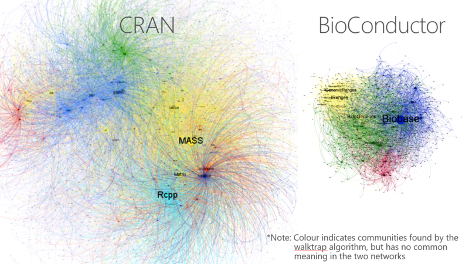

[CRAN](https://cran.r-project.org/web/packages/) and [Bioconductor](https://www.bioconductor.org/) are the main package repositories of R.  
[Github](http://github.com) contains lots of packages.

## Installing new packages

- Packages on CRAN can be installed using function `install.packages()`.

  ```r
  install.packages("<PACKAGE NAME>")
  ```

- Other sources:
  - In Bioconductor:

  ```r
  BiocManager::install("<PACKAGE NAME>")
  ```

  - Github:

  ```r
  remotes::install_github("<REPOSITORY NAME>")
  ```

- In RStudio, inside `Packages` pane:
  - Install new packages using *Install* menu.

## Importing and exporting data

## Packages to import/export data

- `readr`: Read Rectangular Text Data  
  https://cran.r-project.org/web/packages/readr/index.html
- `readxl`: Read Excel Files  
  https://cran.r-project.org/web/packages/readxl/index.html
- `writexl`: Export Data Frames to Excel ‘xlsx’ Format  
  https://cran.r-project.org/web/packages/writexl/index.html
- `haven`: Import and Export ‘SPSS’, ‘Stata’ and ‘SAS’ Files  
  https://cran.r-project.org/web/packages/haven/index.html

More:

- `googlesheets4`: Access Google Sheets using the Sheets API V4  
  https://cran.r-project.org/web/packages/googlesheets4/index.html
- `Microsoft365R`: Interface to the ‘Microsoft 365’ Suite of Cloud Services  
  https://cran.r-project.org/web/packages/Microsoft365R/index.html

## RData files

- To save different R objects into a file.

```r
save(..., file = "filename.RData")
```

Example. Saving objects `table01` and `vector2` into a file named `my_file.RData`.

```r
save(table01, vector2, file = 'my_file.RData')
```

- To recover a saved RData file,

```r
load("filename.RData")
```

## `readr`: Read Rectangular Text Data

- `read_csv()`, `read_csv2()` and `read_delim()`
- In RStudio, inside `Environment` pane:
  - Import a text file using *Import Dataset \(\rightarrow\) From Text (`readr`)* menu.
  - **Avoid** importing using *Import Dataset \(\rightarrow\) From Text (`base`)* menu.

## `readxl`: Read Excel Files

- In RStudio, inside `Environment` pane:
  - Import an excel file using *Import Dataset \(\rightarrow\) From Excel* menu.

## `haven`: ‘SPSS’, ‘Stata’ and ‘SAS’ Files

- In RStudio, inside `Environment` pane:
  - Import a file from another statistical software using *Import Dataset \(\rightarrow\) From SPSS* or *From SAS* or *From Stata* menus.